# Exercices in linear models and experimental design

Alex Sánchez

# Introduction

These exercises describe experimental situations that have been studied using some omics technology like microarrays.

# Comparison between three types of breast cancer

This case study is based on a paer published in http://www.ncbi.nlm.nih.gov/pubmed/15897907 whose data are available in GEO as series GSE1561 series on the following link http://www.ncbi.nlm.nih.gov/geo/query/acc.cgi?acc=GSE1561

The researchers investigated three types of breast cancer tumors: apocrine (APO), basal (BAS) and luminal (LUMI). The classification is based on the resistance of tumors to estrogen and androgen receptors.

- Tumors classified as “APO” are negative for estrogen receptor (ER-) and positive for the androgen receptor (AR +).
- Those classified as “LUMI” are ER + and AR + and
- Those classified as “BAS” are ER- and AR.

The assignment of each sample to an experimental group can be obtained from this link: http://www.ncbi.nlm.nih.gov/geo/gds/profileGraph.cgi?gds=1329

Obviously this is an observational study but its analysis can be done using a linear model approach as well.

1. Identify the experimental factors and their levels.
2. Write down the design matrix associated with this study design.
3. Build the contrast matrix needed to compare each tumor type with the oher two, that is:
   1. “APO” vs “LUMI”
   2. “APO” vs “BAS”
   3. “LUMI” vas “BAS”

```
##  [1] TRUE TRUE TRUE TRUE TRUE TRUE TRUE TRUE TRUE TRUE TRUE TRUE TRUE TRUE
## [15] TRUE
```

```
##      A B L
## PF14 1 0 0
## PF19 1 0 0
## PF23 1 0 0
## PF39 1 0 0
## PF46 1 0 0
## PF24 0 1 0
## PF25 0 1 0
## PF28 0 1 0
## PF34 0 1 0
## PF42 0 1 0
## PF15 0 0 1
## PF32 0 0 1
## PF33 0 0 1
## PF43 0 0 1
## PF47 0 0 1
```

```
##      A B L
## PF14 1 0 0
## PF19 1 0 0
## PF23 1 0 0
## PF39 1 0 0
## PF46 1 0 0
## PF24 0 1 0
## PF25 0 1 0
## PF28 0 1 0
## PF34 0 1 0
## PF42 0 1 0
## PF15 0 0 1
## PF32 0 0 1
## PF33 0 0 1
## PF43 0 0 1
## PF47 0 0 1
## attr(,"assign")
## [1] 1 1 1
## attr(,"contrasts")
## attr(,"contrasts")$`targets$Group`
## [1] "contr.treatment"
```

```
##                 logFC  AveExpr          t      P.Value    adj.P.Val
## 204667_at   -3.038344 8.651157 -14.361559 5.741537e-11 3.570088e-07
## 215729_s_at  3.452290 6.137595  12.814617 3.438484e-10 1.069025e-06
## 220192_x_at -3.016315 9.521883 -10.859041 4.336167e-09 7.020345e-06
## 214451_at   -5.665059 7.432823 -10.829695 4.516144e-09 7.020345e-06
## 217528_at   -5.622086 6.763101  -9.666279 2.429965e-08 3.021904e-05
## 217284_x_at -4.313116 9.133307  -9.528468 2.994504e-08 3.103304e-05
##                     B
## 204667_at   14.649763
## 215729_s_at 13.150062
## 220192_x_at 10.929050
## 214451_at   10.892594
## 217528_at    9.364339
## 217284_x_at  9.172112
```

```
##                 logFC  AveExpr         t      P.Value    adj.P.Val
## 205009_at    4.735050 8.692478 10.564772 6.544490e-09 3.825574e-05
## 205862_at    3.958563 6.082835  9.984049 1.513074e-08 3.825574e-05
## 205225_at    3.964939 9.300546  9.849848 1.845726e-08 3.825574e-05
## 209443_at    2.198392 7.586226  8.531699 1.448500e-07 2.251694e-04
## 217528_at   -4.429254 6.763101 -7.615395 6.873541e-07 7.313285e-04
## 205696_s_at  2.333785 6.239876  7.600437 7.056885e-07 7.313285e-04
##                     B
## 205009_at   10.134557
## 205862_at    9.435258
## 205225_at    9.267523
## 209443_at    7.489032
## 217528_at    6.102626
## 205696_s_at  6.078916
```

```
##                 logFC   AveExpr          t      P.Value    adj.P.Val
## 204667_at    2.961042  8.651157  13.996171 8.630335e-11 2.992696e-07
## 215729_s_at -3.744599  6.137595 -13.899645 9.625911e-11 2.992696e-07
## 205009_at    5.729322  8.692478  12.783178 3.572393e-10 7.404380e-07
## 205225_at    3.939276  9.300546   9.786095 2.029851e-08 3.155403e-05
## 205862_at    3.774303  6.082835   9.519321 3.036546e-08 3.776248e-05
## 218211_s_at  2.808408 10.932769   8.813925 9.159571e-08 8.529355e-05
##                     B
## 204667_at   14.041551
## 215729_s_at 13.954983
## 205009_at   12.894914
## 205225_at    9.423369
## 205862_at    9.062813
## 218211_s_at  8.063263
```

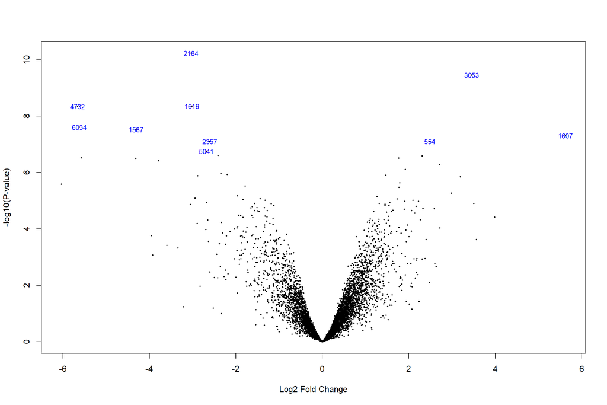

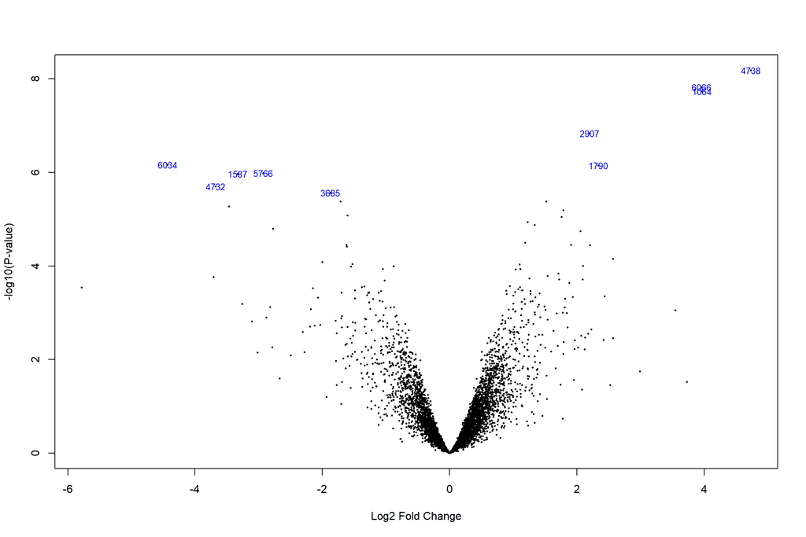

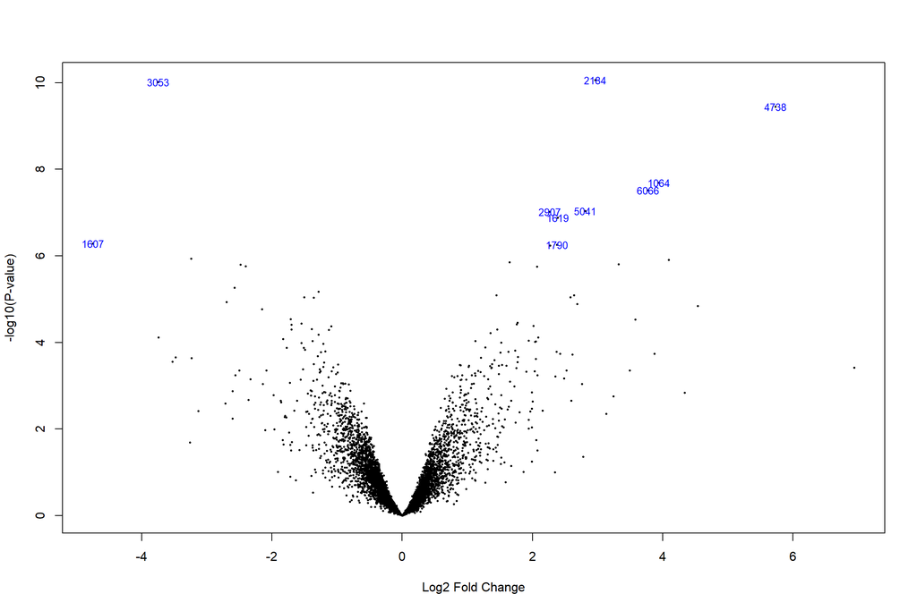